# Recognition of weight lifting exercises

January 30, 2016

## 1. Background

This project is to use proper machine learning method to investigate “how (well)” an activity was performed by using data from accelerometers on the belt, forearm, arm, and dumbell of 6 participants. They were asked to perform barbell lifts correctly and incorrectly in 5 different ways. More information is available from the website here: http://groupware.les.inf.puc-rio.br/har

Data are downloaded from the website:

https://d396qusza40orc.cloudfront.net/predmachlearn/pml-training.csv

https://d396qusza40orc.cloudfront.net/predmachlearn/pml-testing.csv

## 2. Get and Clean Data

First of all, we load the library to be used and import raw data as two variables `raw.training` and `raw.testing` from the files downloaded the sites above.

```r
library(caret)
library(randomForest)
raw.training <- read.csv("pml-training.csv",na.strings="NA")
raw.testing <- read.csv("pml-testing.csv",na.strings="NA")
```

We noticed that the datasets have 160 variables and respectively 19,622 and 20 observertions for each.

```r
dim(raw.testing)
```

```
## [1]  20 160
```

```r
dim(raw.training)
```

```
## [1] 19622   160
```

### 2.1 Removing the “NA” and empty columns

Among those 160 variables, many columnes are marked as `NA` or empty values, for example, kurtosis, skewness, max, min, amplitude etc. We try to remove those values in `raw.training` data in order to have a clean dataset before training, named `pretrain`.

```r
check <- apply(raw.training,2,function(x) sum(is.na(x))/length(x))
keep <- names(check[which(check < 0.5)])
pretrain <- raw.training[keep]
```

```r
check <-  apply(pretrain,2,function(x) sum(x=="")/length(x))
keep <- names(check[which(check < 0.5)])
pretrain <- pretrain[keep]
```

### 2.2 Removing zero covariates

Through previous step, the number of variables is reduced to 60. For the next, we are going to remove the zero covariates. `new_window` is recongnized as a zero covariate and is removed from `pretrain`

```r
check <- nearZeroVar(pretrain,saveMetrics=TRUE,names = T)
subset(check,nzv==T)
```

```
##            freqRatio percentUnique zeroVar  nzv
## new_window  47.33005    0.01019264   FALSE TRUE
```

```r
keep <- rownames(subset(check,nzv==F))
pretrain <- pretrain[keep]
```

### 2.3 Removing names, times,etc.

Some variables that are not related to the quantitive record and may mislead the training, such as `X`, `user_names`, `time` etc. we clean them as following.

```r
pretrain <- pretrain[,-(1:6)]
```

So far, the remaining variables are 53 in total.

```r
names(pretrain)
```

```
##  [1] "roll_belt"            "pitch_belt"           "yaw_belt"
##  [4] "total_accel_belt"     "gyros_belt_x"         "gyros_belt_y"
##  [7] "gyros_belt_z"         "accel_belt_x"         "accel_belt_y"
## [10] "accel_belt_z"         "magnet_belt_x"        "magnet_belt_y"
## [13] "magnet_belt_z"        "roll_arm"             "pitch_arm"
## [16] "yaw_arm"              "total_accel_arm"      "gyros_arm_x"
## [19] "gyros_arm_y"          "gyros_arm_z"          "accel_arm_x"
## [22] "accel_arm_y"          "accel_arm_z"          "magnet_arm_x"
## [25] "magnet_arm_y"         "magnet_arm_z"         "roll_dumbbell"
## [28] "pitch_dumbbell"       "yaw_dumbbell"         "total_accel_dumbbell"
## [31] "gyros_dumbbell_x"     "gyros_dumbbell_y"     "gyros_dumbbell_z"
## [34] "accel_dumbbell_x"     "accel_dumbbell_y"     "accel_dumbbell_z"
## [37] "magnet_dumbbell_x"    "magnet_dumbbell_y"    "magnet_dumbbell_z"
## [40] "roll_forearm"         "pitch_forearm"        "yaw_forearm"
## [43] "total_accel_forearm"  "gyros_forearm_x"      "gyros_forearm_y"
## [46] "gyros_forearm_z"      "accel_forearm_x"      "accel_forearm_y"
## [49] "accel_forearm_z"      "magnet_forearm_x"     "magnet_forearm_y"
## [52] "magnet_forearm_z"     "classe"
```

The same variables in `raw.testing` are reserved to perform the final test with 20 observation.

```r
pretest <- raw.testing[names(raw.testing) %in% names(pretrain)]
```

## 3. Training the data with Random Forest

The `pretrain` dataset is divided into two parts (3:1) used for training and testing:

```r
set.seed(61987)
trainInd <- createDataPartition(pretrain$classe, p=0.75, list=F)
train <- pretrain[trainInd,]
test <- pretrain[-trainInd,]
```

```r
set.seed(1000)
system.time(rf<-randomForest(as.matrix(train[,-53]),train$classe, ntree = 100))
```

```
##    user  system elapsed
##  11.042   0.106  11.163
```

The calcultion time is about 11 seconds and let’s take a look at error evaluated with the numbers of trees increasing:

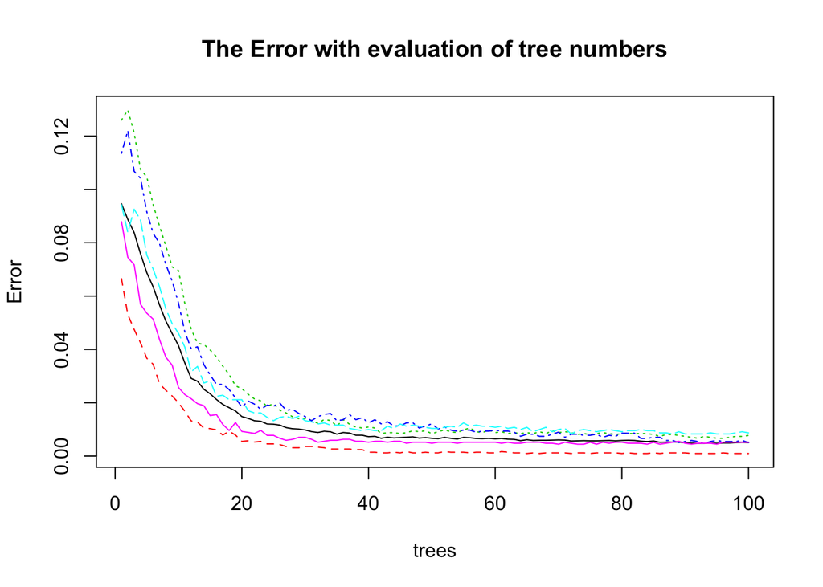

The error is almost unchanged when the tree numbers reach 70. So let’s try again with random forest by modifying `ntree = 70`

```r
set.seed(1000)
system.time(rf<-randomForest(as.matrix(train[,-53]),train$classe, ntree = 70))
```

```
##    user  system elapsed
##   8.012   0.052   8.109
```

The importance of variables (first 20) can be seen in below picture. The most three important variables are `roll_belt`, `yaw_belt` and `pitch_forearm`.

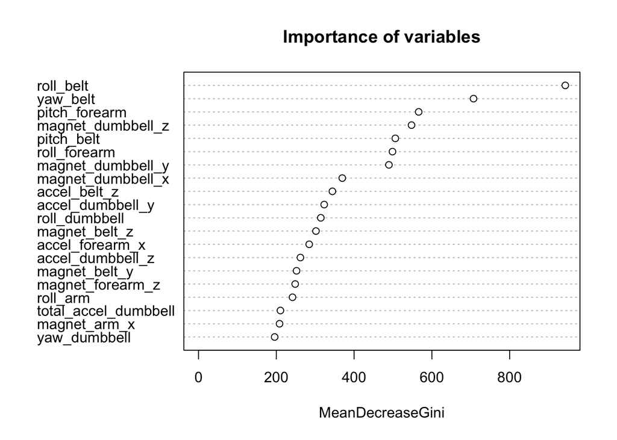

Then the result of testing is quite satisfactory, with an accurancy of 99.39%.

```r
confusionMatrix(test$classe,predict(rf,test))
```

```
## Confusion Matrix and Statistics
##
##           Reference
## Prediction    A    B    C    D    E
##          A 1394    1    0    0    0
##          B    4  940    5    0    0
##          C    0    7  844    4    0
##          D    0    0    6  797    1
##          E    0    0    0    2  899
##
## Overall Statistics
##
##                Accuracy : 0.9939
##                  95% CI : (0.9913, 0.9959)
##     No Information Rate : 0.2851
##     P-Value [Acc > NIR] : < 2.2e-16
##
##                   Kappa : 0.9923
##  Mcnemar's Test P-Value : NA
##
## Statistics by Class:
##
##                      Class: A Class: B Class: C Class: D Class: E
## Sensitivity            0.9971   0.9916   0.9871   0.9925   0.9989
## Specificity            0.9997   0.9977   0.9973   0.9983   0.9995
## Pos Pred Value         0.9993   0.9905   0.9871   0.9913   0.9978
## Neg Pred Value         0.9989   0.9980   0.9973   0.9985   0.9998
## Prevalence             0.2851   0.1933   0.1743   0.1637   0.1835
## Detection Rate         0.2843   0.1917   0.1721   0.1625   0.1833
## Detection Prevalence   0.2845   0.1935   0.1743   0.1639   0.1837
## Balanced Accuracy      0.9984   0.9946   0.9922   0.9954   0.9992
```

## 4. Cross Validation and Expected Out of Sample Error

We use k-fold cross validation setting `k=6`. Each subset is used for training and testing. The result of each validation is quite satisfactory with a minimum value of 0.9936, showing good reliability of random forest method to sovle the problem. The **expected out of sample accurancy** is 99.54% and the **expected out of sample error** is 0.46% for the final model.

```r
K=6
set.seed(1000)
folds <- createFolds(y=pretrain$classe,k=K,list=T,returnTrain=TRUE)
accurancy <- NULL
time <- NULL
for (i in 1:K) {
        traincv <- pretrain[folds[[i]],]
        testcv <- pretrain[-folds[[i]],]
        set.seed(1000)
        t1<-Sys.time()
        rfcv <- randomForest(as.matrix(traincv[,-53]),traincv$classe,ntree=70)
        t2<-Sys.time()
        time[i]=t2-t1
        pred <- predict(rfcv,testcv)
        accurancy[i] <- sum(pred==testcv$classe)/length(testcv$classe)
}
```

```r
summary(accurancy)
```

```
##    Min. 1st Qu.  Median    Mean 3rd Qu.    Max.
##  0.9936  0.9950  0.9956  0.9954  0.9962  0.9966
```

The calculation time for each validation is around 9 seconds.

[output not shown]

## 5. Predict 20 Obersavtions

We use all the given training data to train the random forest model and use the model o predict 20 unknown cases, then results are shown as follows.

```r
set.seed(1000)
pred <- predict(randomForest(as.matrix(pretrain[,-53]),pretrain$classe,ntree = 70),pretest)
print(pred)
```

```
##  1  2  3  4  5  6  7  8  9 10 11 12 13 14 15 16 17 18 19 20
##  B  A  B  A  A  E  D  B  A  A  B  C  B  A  E  E  A  B  B  B
## Levels: A B C D E
```

## 6. Why choose random forest model?

We have compared random forest model with some other popular classification models such as *GBM* and *LDA* in the regards of time complexity and accurancy, random forest shows a better performance among them.

### 6.1 GBM method

The gbm method goes terribly slow in `caret` package by following code:

```r
modGbm <- train(train$classe~., data=train, method='gbm',verbose=F)
```

Thus we use `gbm` package which is actually much faster.

```r
library(gbm)
set.seed(1000)
system.time(gbm <- gbm(classe ~., data=train, n.trees=1000, distribution="multinomial"))
```

```
##    user  system elapsed
##  86.752   0.643  87.661
```

```r
pred.gbm <-as.data.frame(predict(gbm,test,n.trees = gbm$n.trees))
pred.gbm$result <- apply(pred.gbm,1,which.max)
pred.gbm$result <- LETTERS[pred.gbm$result]
confusionMatrix(test$classe,pred.gbm$result)
```

```
## Confusion Matrix and Statistics
##
##           Reference
## Prediction    A    B    C    D    E
##          A 1114   31   66  163   21
##          B  368  379  113   89    0
##          C  305   42  431   77    0
##          D  246   32   44  482    0
##          E  134  180   86   80  421
##
## Overall Statistics
##
##                Accuracy : 0.5765
##                  95% CI : (0.5625, 0.5904)
##     No Information Rate : 0.4419
##     P-Value [Acc > NIR] : < 2.2e-16
##
##                   Kappa : 0.4538
##  Mcnemar's Test P-Value : < 2.2e-16
##
## Statistics by Class:
##
##                      Class: A Class: B Class: C Class: D Class: E
## Sensitivity            0.5141  0.57078  0.58243  0.54097  0.95249
## Specificity            0.8973  0.86557  0.89817  0.91976  0.89242
## Pos Pred Value         0.7986  0.39937  0.50409  0.59950  0.46726
## Neg Pred Value         0.6999  0.92794  0.92368  0.90024  0.99475
## Prevalence             0.4419  0.13540  0.15090  0.18169  0.09013
## Detection Rate         0.2272  0.07728  0.08789  0.09829  0.08585
## Detection Prevalence   0.2845  0.19352  0.17435  0.16395  0.18373
## Balanced Accuracy      0.7057  0.71817  0.74030  0.73036  0.92246
```

### 6.2 LDA method

Then we tried LDA methode, it takes 14 seconds and the accurancy is 69%

```r
system.time(lda <- train(train$classe ~.,data=train,method="lda",verbose=F))
```

```
##    user  system elapsed
##  13.073   1.165  14.324
```

```r
confusionMatrix(test$classe,predict(lda,test))
```

```
## Confusion Matrix and Statistics
##
##           Reference
## Prediction    A    B    C    D    E
##          A 1115   34  122  119    5
##          B  160  589  116   33   51
##          C   73   86  564  111   21
##          D   38   42   90  602   32
##          E   31  157   78   99  536
##
## Overall Statistics
##
##                Accuracy : 0.6945
##                  95% CI : (0.6814, 0.7074)
##     No Information Rate : 0.2889
##     P-Value [Acc > NIR] : < 2.2e-16
##
##                   Kappa : 0.6139
##  Mcnemar's Test P-Value : < 2.2e-16
##
## Statistics by Class:
##
##                      Class: A Class: B Class: C Class: D Class: E
## Sensitivity            0.7869   0.6487   0.5814   0.6245   0.8310
## Specificity            0.9197   0.9099   0.9260   0.9487   0.9143
## Pos Pred Value         0.7993   0.6207   0.6596   0.7488   0.5949
## Neg Pred Value         0.9139   0.9193   0.8997   0.9117   0.9728
## Prevalence             0.2889   0.1852   0.1978   0.1966   0.1315
## Detection Rate         0.2274   0.1201   0.1150   0.1228   0.1093
## Detection Prevalence   0.2845   0.1935   0.1743   0.1639   0.1837
## Balanced Accuracy      0.8533   0.7793   0.7537   0.7866   0.8727
```

For the same training and testing data, we have following results:

[output not shown]

From above experiments, we can see clearly that random forest is an efficient and reliable method to solve in this problem.